# Homework 1

#### IE 582 Statistical Learning for Data Mining

##### Homework 1

##### Fatih Mehmet Yılmaz - 2024702054

```python
# Import necessary libraries
import pandas as pd
import numpy as np
import matplotlib.pyplot as plt
import seaborn as sns
from sklearn.preprocessing import StandardScaler
from sklearn.decomposition import PCA
from sklearn.linear_model import LinearRegression
from sklearn.metrics import mean_squared_error, r2_score
from sklearn.model_selection import train_test_split

import warnings
warnings.filterwarnings("ignore")
```

```python
# Load the design parameter data
input_data = pd.read_csv('hw1_input.csv')

# Load the real and imaginary parts of S11
real_data = pd.read_csv('hw1_real.csv')
imag_data = pd.read_csv('hw1_img.csv')

# Calculate the magnitude of S11
magnitude = np.sqrt(real_data**2 + imag_data**2)
```

```python
# First simple check of the data

print("Input Data Shape:", input_data.shape)
print("Real Part of S11 Shape:", real_data.shape)
print("Imaginary Part of S11 Shape:", imag_data.shape)
print("\nInput Data Info:")
print(input_data.info())
```

```
Input Data Shape: (385, 11)
Real Part of S11 Shape: (385, 201)
Imaginary Part of S11 Shape: (385, 201)

Input Data Info:
<class 'pandas.core.frame.DataFrame'>
RangeIndex: 385 entries, 0 to 384
Data columns (total 11 columns):
 #   Column                                      Non-Null Count  Dtype
---  ------                                      --------------  -----
 0   length of patch                             385 non-null    float64
 1   width of patch                              385 non-null    float64
 2   height of patch                             385 non-null    float64
 3   height of substrate                         385 non-null    float64
 4   height of solder resist layer               385 non-null    float64
 5   radius of the probe                         385 non-null    float64
 6   c_pad                                       385 non-null    float64
 7   c_antipad                                   385 non-null    float64
 8   c_probe                                     385 non-null    float64
 9   dielectric constant of substrate            385 non-null    float64
 10  dielectric constant of solder resist layer  385 non-null    float64
dtypes: float64(11)
memory usage: 33.2 KB
None
```

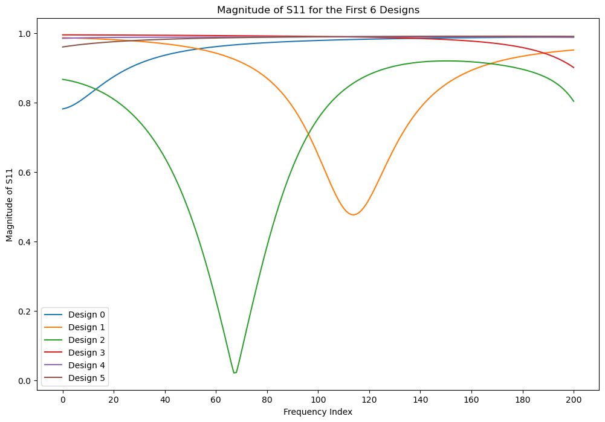

```python
# Check the magnitude to be had comparing to the graph given in the HW statement

plt.figure(figsize=(12, 8))
for i in range(6):
    plt.plot(magnitude.iloc[i], label=f'Design {i}')

plt.xlabel('Frequency Index')
plt.ylabel('Magnitude of S11')
plt.title('Magnitude of S11 for the First 6 Designs')
plt.legend()
plt.grid(False)
plt.xticks(ticks=np.arange(0, 201, 20), labels=np.arange(0, 201, 20))
plt.show()
```

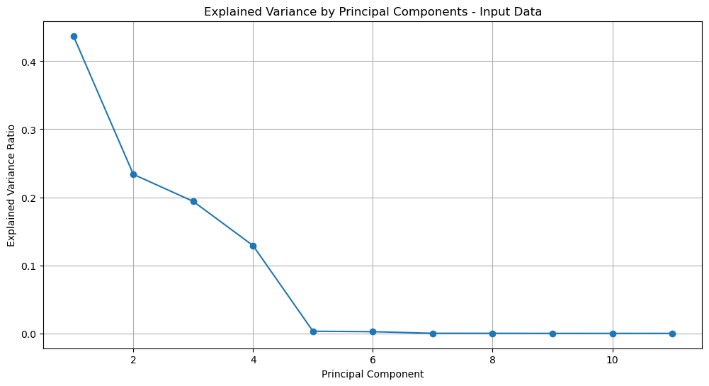

```python
# PCA on input design parameters to find optimal component count
pca_input = PCA()
pca_input.fit(input_data)

# Plot the explained variance ratio for design parameters
plt.figure(figsize=(12, 6))
plt.plot(range(1, len(pca_input.explained_variance_ratio_) + 1), pca_input.explained_variance_ratio_, marker='o')
plt.title('Explained Variance by Principal Components - Input Data')
plt.xlabel('Principal Component')
plt.ylabel('Explained Variance Ratio')
plt.grid(True)
plt.show()
```

```python
# Decide on the number of components based on explained variance
n_components_input = 4  # Adjust based on the plot
pca_input = PCA(n_components=n_components_input)
principal_components_input = pca_input.fit_transform(input_data)

# Create a DataFrame for the principal components of input data
principal_df_input = pd.DataFrame(data=principal_components_input, columns=[f'PC{i+1}' for i in range(n_components_input)])
```

```python
# Get the explained variance ratio
explained_variance = pca_input.explained_variance_ratio_
principal_components = pd.DataFrame(pca_input.components_, columns=input_data.columns)

# Total variance explained by each component
total_variance_explained = np.cumsum(explained_variance)
print("\nTotal Variance Explained by Principal Components:")
for i, variance in enumerate(total_variance_explained):
    print(f"PC{i+1}: {variance:.4f}")
```

```
Total Variance Explained by Principal Components:
PC1: 0.4372
PC2: 0.6709
PC3: 0.8650
PC4: 0.9940
```

In this part, the number of principal components is selected based on the total explained variance.

As it can be seen from the graph and the output, the total explained by principal components is more than 99% when n_components is 4.

```
Real Part - Mean Squared Error: 0.1931, R^2 Score: 0.1163
Imaginary Part - Mean Squared Error: 0.1412, R^2 Score: 0.0142
```

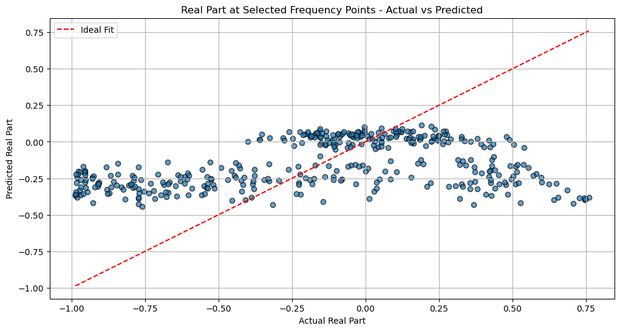

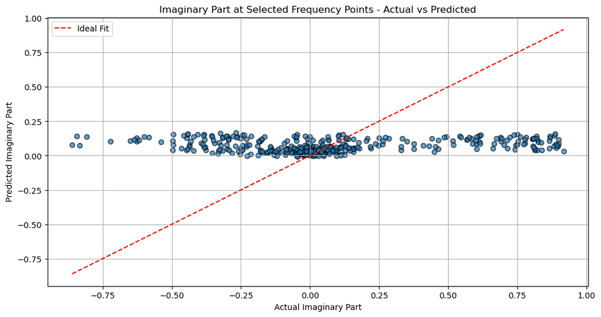

```python
selected_frequencies = magnitude.idxmin(axis=1).astype(int)  # Ensure indices are integers
X = principal_components_input
y_real = real_data.to_numpy()[np.arange(len(real_data)), selected_frequencies]
y_imag = imag_data.to_numpy()[np.arange(len(imag_data)), selected_frequencies]

# Initialize and fit linear regression models for real and imaginary parts
model_real = LinearRegression()
model_imag = LinearRegression()

model_real.fit(X, y_real)
model_imag.fit(X, y_imag)

# Predict the real and imaginary components of S11 at selected frequency points
y_real_pred = model_real.predict(X)
y_imag_pred = model_imag.predict(X)

# Evaluate the models using Mean Squared Error and R^2 score
mse_real = mean_squared_error(y_real, y_real_pred)
r2_real = r2_score(y_real, y_real_pred)
mse_imag = mean_squared_error(y_imag, y_imag_pred)
r2_imag = r2_score(y_imag, y_imag_pred)

print(f"Real Part - Mean Squared Error: {mse_real:.4f}, R^2 Score: {r2_real:.4f}")
print(f"Imaginary Part - Mean Squared Error: {mse_imag:.4f}, R^2 Score: {r2_imag:.4f}")

# Plot actual vs predicted values for the real part at selected frequency points
plt.figure(figsize=(12, 6))
plt.scatter(y_real, y_real_pred, edgecolor='k', alpha=0.7)
plt.plot([y_real.min(), y_real.max()], [y_real.min(), y_real.max()], 'r--', label="Ideal Fit")
plt.xlabel('Actual Real Part')
plt.ylabel('Predicted Real Part')
plt.title('Real Part at Selected Frequency Points - Actual vs Predicted')
plt.legend()
plt.grid(True)
plt.show()

# Plot actual vs predicted values for the imaginary part at selected frequency points
plt.figure(figsize=(12, 6))
plt.scatter(y_imag, y_imag_pred, edgecolor='k', alpha=0.7)
plt.plot([y_imag.min(), y_imag.max()], [y_imag.min(), y_imag.max()], 'r--', label="Ideal Fit")
plt.xlabel('Actual Imaginary Part')
plt.ylabel('Predicted Imaginary Part')
plt.title('Imaginary Part at Selected Frequency Points - Actual vs Predicted')
plt.legend()
plt.grid(True)
plt.show()
```

```
Real Part - Mean Squared Error: 0.1918, R^2 Score: 0.1224
Imaginary Part - Mean Squared Error: 0.1417, R^2 Score: 0.0107
```

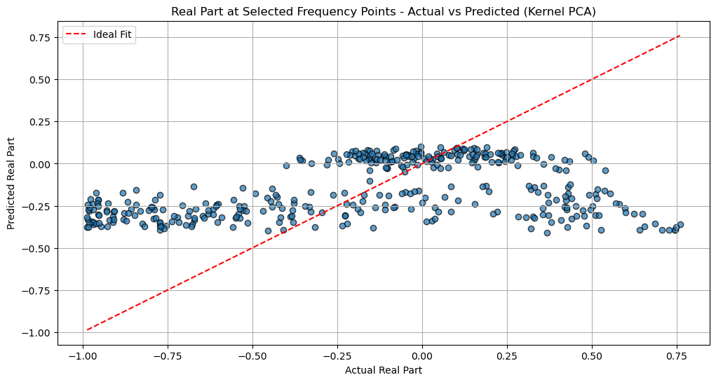

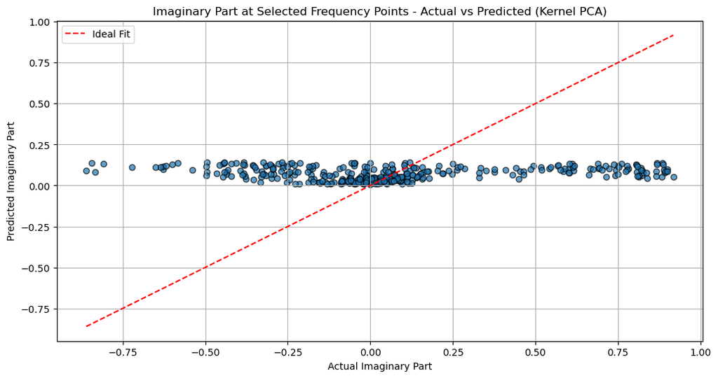

```python
import pandas as pd
import numpy as np
from sklearn.decomposition import KernelPCA
from sklearn.linear_model import LinearRegression
from sklearn.metrics import mean_squared_error, r2_score
import matplotlib.pyplot as plt

# Load the design parameter data
input_data = pd.read_csv('hw1_input.csv')

# Load the real and imaginary parts of S11
real_data = pd.read_csv('hw1_real.csv')
imag_data = pd.read_csv('hw1_img.csv')

# Calculate the magnitude of S11
magnitude = np.sqrt(real_data**2 + imag_data**2)

# Find the frequency index where the minimum magnitude occurs for each row
selected_frequencies = magnitude.idxmin(axis=1).astype(int)  # Ensure indices are integers

# Extract the real and imaginary parts at the selected frequencies
y_real = real_data.to_numpy()[np.arange(len(real_data)), selected_frequencies]
y_imag = imag_data.to_numpy()[np.arange(len(imag_data)), selected_frequencies]

# Apply Kernel PCA to the input data for dimensionality reduction
n_components = 4  # Choose the desired number of components
kernel_pca = KernelPCA(n_components=n_components, kernel='rbf', gamma=0.1)  # Adjust gamma based on data
X_kpca = kernel_pca.fit_transform(input_data)

# Initialize and fit linear regression models for the Kernel PCA transformed data
model_real = LinearRegression()
model_imag = LinearRegression()

model_real.fit(X_kpca, y_real)
model_imag.fit(X_kpca, y_imag)

# Predict the real and imaginary components of S11 at selected frequency points
y_real_pred = model_real.predict(X_kpca)
y_imag_pred = model_imag.predict(X_kpca)

# Evaluate the models using Mean Squared Error and R^2 score
mse_real = mean_squared_error(y_real, y_real_pred)
r2_real = r2_score(y_real, y_real_pred)
mse_imag = mean_squared_error(y_imag, y_imag_pred)
r2_imag = r2_score(y_imag, y_imag_pred)

print(f"Real Part - Mean Squared Error: {mse_real:.4f}, R^2 Score: {r2_real:.4f}")
print(f"Imaginary Part - Mean Squared Error: {mse_imag:.4f}, R^2 Score: {r2_imag:.4f}")

# Plot actual vs predicted values for the real part at selected frequency points
plt.figure(figsize=(12, 6))
plt.scatter(y_real, y_real_pred, edgecolor='k', alpha=0.7)
plt.plot([y_real.min(), y_real.max()], [y_real.min(), y_real.max()], 'r--', label="Ideal Fit")
plt.xlabel('Actual Real Part')
plt.ylabel('Predicted Real Part')
plt.title('Real Part at Selected Frequency Points - Actual vs Predicted (Kernel PCA)')
plt.legend()
plt.grid(True)
plt.show()

# Plot actual vs predicted values for the imaginary part at selected frequency points
plt.figure(figsize=(12, 6))
plt.scatter(y_imag, y_imag_pred, edgecolor='k', alpha=0.7)
plt.plot([y_imag.min(), y_imag.max()], [y_imag.min(), y_imag.max()], 'r--', label="Ideal Fit")
plt.xlabel('Actual Imaginary Part')
plt.ylabel('Predicted Imaginary Part')
plt.title('Imaginary Part at Selected Frequency Points - Actual vs Predicted (Kernel PCA)')
plt.legend()
plt.grid(True)
plt.show()
```

The evaluation metrics indicate that the linear regression model is not very effective at predicting the real and imaginary components of 𝑆 11 S 11  based on the geometric parameters of the antenna design:

Interpretation of Metrics Mean Squared Error (MSE):

The MSE values (0.1931 for the real part and 0.1412 for the imaginary part) alone don’t provide a direct measure of goodness-of-fit, but they do indicate the magnitude of prediction errors. These values are not extremely high, which means the model isn’t wildly off, but they also aren’t as low as one would hope for accurate predictions. 𝑅 2 R 2 Score:

The 𝑅 2 R 2 scores are low (0.1163 for the real part and 0.0142 for the imaginary part), indicating that the linear model is explaining very little of the variance in the 𝑆 11 S 11  values. An 𝑅 2 R 2 score of 0.1163 for the real part suggests that only about 11.6% of the variance in the real part of 𝑆 11 S 11  can be explained by the model. For the imaginary part, the 𝑅 2 R 2 score of 0.0142 implies that the model is essentially not capturing any meaningful relationship (only 1.4% of variance is explained). Insights from the Results These low 𝑅 2 R 2 scores suggest that:

Nonlinearity: The relationship between the geometric parameters and the real/imaginary parts of 𝑆 11 S 11  at the selected frequency points is likely nonlinear. A linear model is too simplistic to capture these complex interactions. Limited Predictive Power: Linear regression might be unable to capture certain aspects of the data. This could result from intricate dependencies in the electromagnetic field interactions that can’t be easily described by a linear model. Recommendations Given these results, you might consider the following steps to improve prediction accuracy:

Use Nonlinear Models:

Support Vector Regression (SVR): SVR with a nonlinear kernel (e.g., RBF) could model complex relationships between geometry and 𝑆 11 S 11  . Random Forest Regression: A tree-based method like random forest can capture nonlinear interactions without extensive tuning, providing a robust baseline for comparison. Neural Networks: A neural network model, particularly with multiple layers, can capture intricate nonlinear relationships, though it requires more data and careful tuning. Feature Engineering:

Consider engineering additional features from the geometric parameters. For example, if any parameters interact with each other in the design, including interaction terms could improve predictive power. Regularized Linear Models:

If you want to stay within linear models, try using Ridge or Lasso regression. These regularization techniques might handle potential multicollinearity among geometric parameters, though they are still linear models and may not perform significantly better. Dimensionality Reduction for Nonlinear Models:

Keep the PCA-reduced input space for ease of processing but explore alternative techniques such as kernel PCA to capture nonlinear structure in the input features. Evaluate Alternative Models with Cross-Validation:

Use cross-validation to assess the performance of alternative models consistently and ensure the robustness of your chosen approach. Conclusion The low 𝑅 2 R 2 scores indicate that a more sophisticated model is needed to better predict the real and imaginary components of 𝑆 11 S 11  . Nonlinear models like SVR, random forests, or neural networks are likely to provide a more accurate mapping between the antenna geometry and the 𝑆 11 S 11  response, potentially improving both 𝑅 2 R 2 scores and reducing the MSE.